# Cyclist Case Study

Dhivya Iyer

8/3/2021

## Scenario

In 2016, Cyclistic launched a successful bike-share offering. Since then, the program has grown to a fleet of 5,824 bicycles that are geotracked and locked into a network of 692 stations across Chicago. The bikes can be unlocked from one station and returned to any other station in the system anytime.

Until now, Cyclistic’s marketing strategy relied on building general awareness and appealing to broad consumer segments. One approach that helped make these things possible was the flexibility of its pricing plans: single-ride passes, full-day passes, and annual memberships. Customers who purchase single-ride or full-day passes are referred to as casual riders. Customers who purchase annual memberships are Cyclistic members.

Cyclistic’s finance analysts have concluded that annual members are much more profitable than casual riders. Although the pricing flexibility helps Cyclistic attract more customers, Moreno believes that maximizing the number of annual members will be key to future growth. Rather than creating a marketing campaign that targets all-new customers, Moreno believes there is a very good chance to convert casual riders into members. She notes that casual riders are already aware of the Cyclistic program and have chosen Cyclistic for their mobility needs.

Moreno has set a clear goal: Design marketing strategies aimed at converting casual riders into annual members. In order to do that, however, the marketing analyst team needs to better understand how annual members and casual riders differ, why casual riders would buy a membership, and how digital media could affect their marketing tactics. Moreno and her team are interested in analyzing the Cyclistic historical bike trip data to identify trends.

## Dataset

Source: https://divvy-tripdata.s3.amazonaws.com/index.html

## Objective

How do annual members and casual riders use Cyclistic bikes differently?

## Set up environment

Load the required packages

```r
library('ggplot2')
library("dplyr")
library("tidyverse")
library('plyr')
```

## Prepare and process the data

Since the csv files with the data are very large, I will upload, clean, and filter each file at the same time. A function to do this:

```r
read_clean_filter<-function(filename) {
  read_csv(filename) %>%
    select(member_casual,rideable_type,start_station_name,end_station_name,started_at,ended_at) %>%
    mutate(ride_type=substr(rideable_type,1,nchar(rideable_type)-5)) %>%
    select(-rideable_type)
}
```

```r
all_csv_files = list.files(pattern="*.csv")
all_data <- read_clean_filter(all_csv_files[1])
```

```r
for (i in 11) {
  all_data<-read_clean_filter(all_csv_files[i+1]) %>%
    rbind(all_data)
}
```

```r
head(all_data)
```

| member_casual | start_station_name | end_station_name | started_at | ended_at | ride_type |
| --- | --- | --- | --- | --- | --- |
| member | NA | NA | 2021-06-13 14:31:28 | 2021-06-13 14:34:11 | electric |
| member | NA | NA | 2021-06-04 11:18:02 | 2021-06-04 11:24:19 | electric |
| member | NA | NA | 2021-06-04 09:49:35 | 2021-06-04 09:55:34 | electric |
| member | NA | NA | 2021-06-03 19:56:05 | 2021-06-03 20:21:55 | electric |
| member | NA | NA | 2021-06-04 14:05:51 | 2021-06-04 14:09:59 | electric |
| member | NA | NA | 2021-06-03 19:32:01 | 2021-06-03 19:38:46 | electric |

## Check data with NA values

```r
na_data<-all_data %>%
  filter(is.na(start_station_name))
na_data<-all_data %>%
  filter(is.na(end_station_name)) %>%
  rbind(na_data)
nrow(na_data)/nrow(all_data)
```

```
[1] 0.1308245
```

Since about 13% of the data has NA values, I want to see if removing these rows will skew the data.

```r
distinct(na_data,member_casual)
```

| member_casual |
| --- |
| member |
| casual |

```r
distinct(na_data,ride_type)
```

| ride_type |
| --- |
| electric |
| classic |
| docked |

The rows with NA values have all types of customers and rides.

Now I will check if one category is overepresented in the rows with NA values.

```r
na_r_count<-count(na_data$ride_type) %>%
  dplyr::rename(na_count=freq)

na_mc_count<-count(na_data$member_casual) %>%
  dplyr::rename(na_count=freq)

all_r_count<-count(all_data$ride_type) %>%
  dplyr::rename(all_count=freq)

all_mc_count<-count(all_data$member_casual) %>%
  dplyr::rename(all_count=freq)

ride_type_count<-merge(na_r_count,all_r_count) %>%
  mutate(percent_na=na_count/all_count)

customer_type_count<-merge(na_mc_count,all_mc_count) %>%
  mutate(percent_na=na_count/all_count)

na_percent_count<-rbind(ride_type_count,customer_type_count)
```

```r
na_percent_count
```

| x | na_count | all_count | percent_na |
| --- | --- | --- | --- |
| classic | 1233 | 435020 | 0.002834352 |
| docked | 770 | 601261 | 0.001280642 |
| electric | 165593 | 244794 | 0.676458573 |
| casual | 93145 | 639977 | 0.145544293 |
| member | 74451 | 641098 | 0.116130451 |

About 68% of the rides with electric bikes have NA data so removing these rows would severely skew the data. Excluding the station names, I will check if there still any more NA values to be analyzed.

```r
nrow(all_data)
```

```
[1] 1281075
```

```r
all_data %>%
  select(-start_station_name) %>%
  select(-end_station_name) %>%
  drop_na() %>%
  nrow()
```

```
[1] 1281075
```

The length of this cleaned data frame is the same as the original so there are no more NAs to check.

## Analyze the data

Now I will analyze what types of bikes members and casual customers tend to use.

```r
customer_types<- count(filter(all_data,member_casual=="member")$ride_type) %>%
  dplyr::rename(member=freq)

customer_types<- count(filter(all_data,member_casual=="casual")$ride_type) %>%
  dplyr::rename(casual=freq) %>%
  merge(customer_types)

total_row<-data.frame(
  x="Total",
  casual=sum(customer_types$casual),
  member=sum(customer_types$member),
  stringsAsFactors = FALSE
)

customer_types_total<-rbind(customer_types,total_row)

total_column<-data.frame(
  Total=rowSums(customer_types[2:3])
)

customer_types_total<-mutate(customer_types,Total=total_column)
customer_types_total
```

| x | casual | member | Total |
| --- | --- | --- | --- |
| classic | 188245 | 246775 |  |
| docked | 320172 | 281089 |  |
| electric | 131560 | 113234 |  |

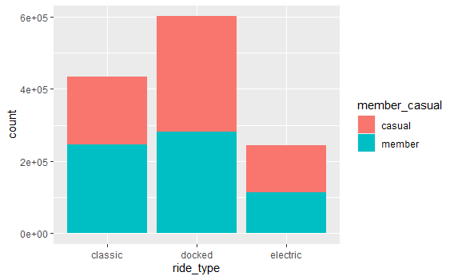

```r
all_data %>%
  select(ride_type,member_casual) %>%
  ggplot()+
    geom_bar(mapping=aes(x=ride_type,fill=member_casual))
```

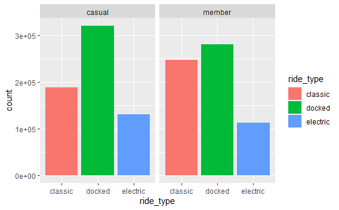

```r
all_data %>%
  select(ride_type,member_casual) %>%
  ggplot()+
    geom_bar(mapping=aes(x=ride_type,fill=ride_type))+
    facet_wrap(~member_casual)
```

In order to get a better sense of the types of bikes different customers use, I will make pie charts of the proportions of the customers that use each type of bike.

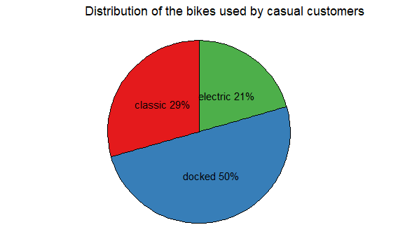

```r
casual_chart<-customer_types %>%
  arrange(desc(x)) %>%
  mutate(prop=casual/sum(customer_types$casual)*100) %>%
  mutate(ypos=cumsum(prop)-0.5*prop)

ggplot(casual_chart, aes(x="", y=prop, fill=x)) +
  geom_bar(stat="identity", width=1,color="black") +
  coord_polar("y", start=0)+
  theme_void()+
  theme(legend.position="none") +
  geom_text(aes(y = ypos, label = paste0(x," ",round(prop),"%")), color = "black", size=4) +
  scale_fill_brewer(palette="Set1")+
  labs(title="Distribution of the bikes used by casual customers")
```

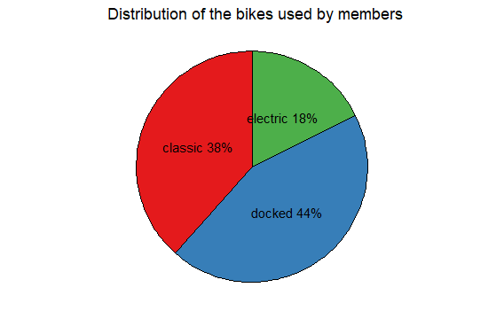

```r
member_chart<-customer_types %>%
  arrange(desc(x)) %>%
  mutate(prop=member/sum(customer_types$member)*100) %>%
  mutate(ypos=cumsum(prop)-0.5*prop)

ggplot(member_chart, aes(x="", y=prop, fill=x)) +
  geom_bar(stat="identity", width=1,color="black") +
  coord_polar("y", start=0)+
  theme_void()+
  theme(legend.position="none") +
  geom_text(aes(y = ypos, label = paste0(x," ",round(prop),"%")), color = "black", size=4) +
  scale_fill_brewer(palette="Set1")+
  labs(title="Distribution of the bikes used by members")
```

This shows that a higher proportion of members use the classic bike than the casual customers.

## Conclusion

Members use the classic bikes more often than the casual customers.